# Size matters: using machine learning techniques to predict the age of abalone from different measures of size

##### Model 2

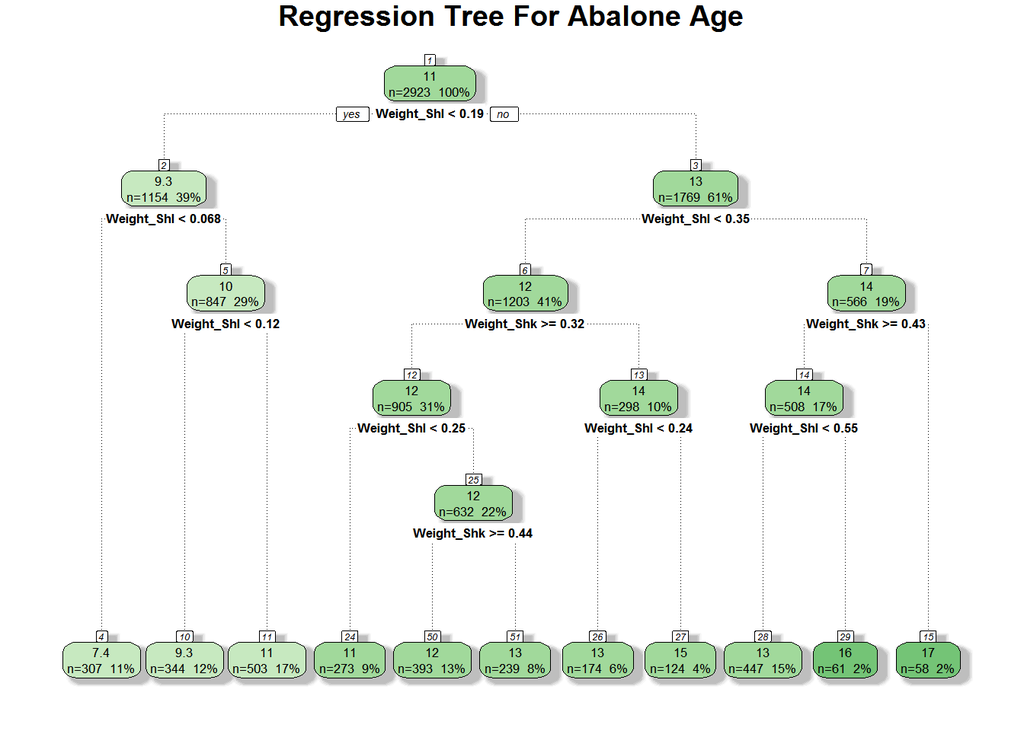

```r
fit=rpart(Age ~ Weight_Shl + Weight_Shk, data=tr_dat)
#prp(fit, varlen=-10, main="Regression tree for Abalone Age", box.col=c("green", "blue")[fit$frame$yval])
#summary(fit)
par(mar=c(1,1,1,1))
fancyRpartPlot(fit, main="Regression Tree For Abalone Age", sub="")
```

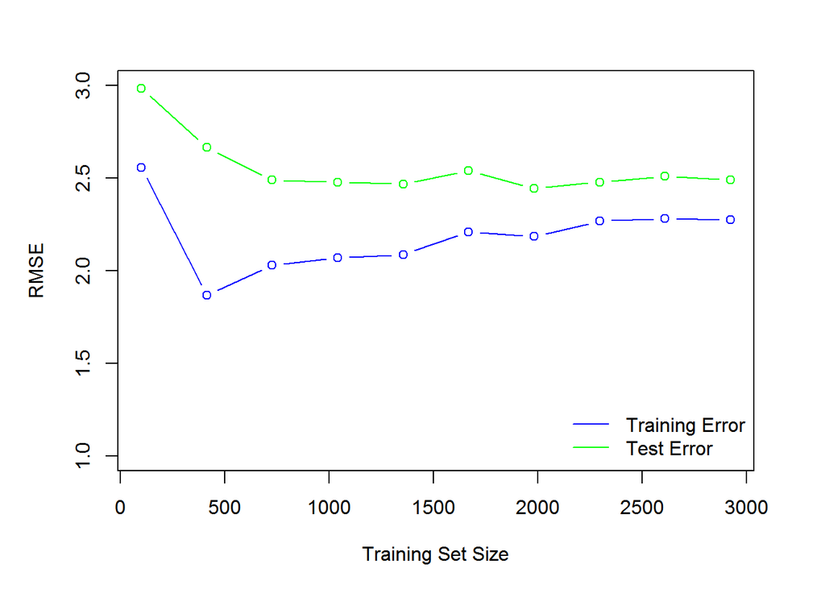

```r
te_errs = c()
tr_errs = c()
te_actual = te_dat$Age
tr_sizes = seq(100, nrow(tr_dat), length.out=10)
for (tr_size in tr_sizes) {
  tr_dat1 = tr_dat[1:tr_size,]
  tr_actual = tr_dat1$Age

  fit=rpart(Age ~ . , data=tr_dat1)

  #training error
  tr_predicted = predict(fit, tr_dat1)
  err = sqrt(mean((tr_actual-tr_predicted)^2))
  tr_errs = c(tr_errs, err)

  #test error
  te_predicted = predict(fit, te_dat)
  err = sqrt(mean((te_actual-te_predicted)^2))
  te_errs = c(te_errs, err)

}
par(mar=c(5,5,3,3))
plot(tr_sizes, tr_errs,  col="blue", main="", type="b", ylim=c(1,3), ylab = "RMSE", xlab = "Training Set Size")
lines(tr_sizes,te_errs, col="green", type="b")
legend("bottomright", c("Training Error","Test Error"), col= c("blue","green"), lty=1,bty="n")
```

#### KNN

##### Full Model

We tested how the full KNN model differed at ks of 1,5,10, and 50. The RMSEs of the full model (above 11 for all ks) using KNN regression were much higher than those from the previously analyzed methods. The learning curves for all ks analyzed suggest that this model has high bias.

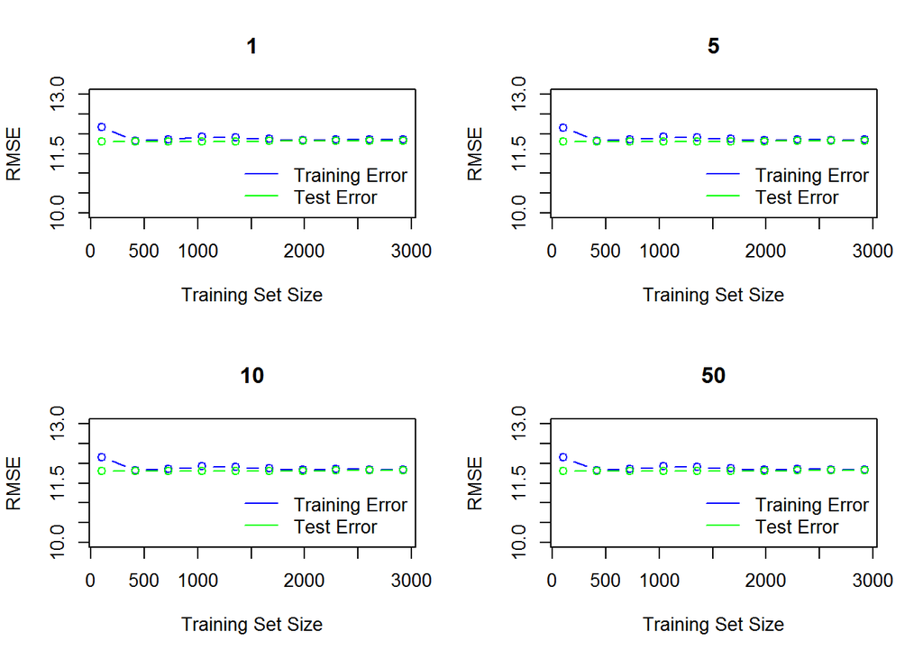

```r
ks = c(1, 5, 10, 50)
par(mfrow=c(2,2))

for(k in ks){
  te_errs = c()
  tr_errs = c()
  te_actual = te_dat$Age
  tr_sizes = seq(100, nrow(tr_dat), length.out=10)


  for (tr_size in tr_sizes) {
    tr_dat1 = tr_dat[1:tr_size,]
    tr_actual = tr_dat1$Age
    fit = knn3(Age ~ Sex + Length + Diameter + Height + Weight_W + Weight_Shk + Weight_V + Weight_Shl, data=tr_dat1, k=k)

    # error on training set
    tr_predicted = predict(fit, tr_dat1)
    err = sqrt(mean((tr_actual-tr_predicted)^2))
    tr_errs = c(tr_errs, err)

    # error on test set
    te_predicted = predict(fit, te_dat)
    err = sqrt(mean((te_actual-te_predicted)^2))
    te_errs = c(te_errs, err)
  }

  # Plot learning curve here
  plot(tr_sizes, tr_errs,  col="blue", main=k, type="b",
       ylim=c(10,13), ylab = "RMSE", xlab = "Training Set Size")
  lines(tr_sizes,te_errs, col="green", type="b")
  legend("bottomright", c("Training Error","Test Error"), col= c("blue","green"),
         lty=1,bty="n")

}
```

##### Model 2

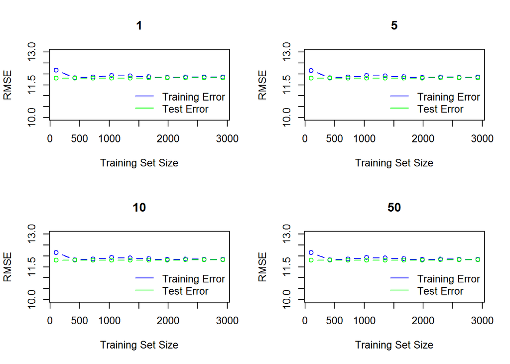

```r
ks = c(1, 5, 10, 50)
par(mfrow=c(2,2))

for(k in ks){
  te_errs = c()
  tr_errs = c()
  te_actual = te_dat$Age
  tr_sizes = seq(100, nrow(tr_dat), length.out=10)


  for (tr_size in tr_sizes) {
    tr_dat1 = tr_dat[1:tr_size,]
    tr_actual = tr_dat1$Age
    fit1 = knn3(Age ~ Diameter + Weight_W, data=tr_dat1, k=k)

    # error on training set
    tr_predicted = predict(fit1, tr_dat1)
    err = sqrt(mean((tr_actual-tr_predicted)^2))
    tr_errs = c(tr_errs, err)

    # error on test set
    te_predicted = predict(fit1, te_dat)
    err = sqrt(mean((te_actual-te_predicted)^2))
    te_errs = c(te_errs, err)
  }

  # Plot learning curve here
  plot(tr_sizes, tr_errs,  col="blue", main=k, type="b",
       ylim=c(10,13), ylab = "RMSE", xlab = "Training Set Size")
  lines(tr_sizes,te_errs, col="green", type="b")
  legend("bottomright", c("Training Error","Test Error"), col= c("blue","green"),
         lty=1,bty="n")

}
```

### References

Warwick J Nash, Tracy L Sellers, Simon R Talbot, Andrew J Cawthorn and Wes B Ford. 1994.The Population Biology of Abalone (*Haliotis* species) in Tasmania. I. Blacklip Abalone (*H. rubra*) from the North Coast and Islands of Bass Strait.Sea Fisheries Division, Technical Report No. 48 (ISSN 1034-3288)